# Philippines Modeling Document

#### Prepared by Reduce.Reuse.Grow.Inc

[figure not shown]

## Abstract

RRG has partnered with the Philippine Eagle Foundation (PEF) to conduct Project ReGAIN throughout the ancestral domain of the Obu-Manuvu on Mindano Island, Philippines. RRG and PEF have partnered to plant 1.5 million trees over ~1500 hectares and is planning the expansion of ~3400 hectares.  
**In total, RRG estimates project activities can sequester 1,208,389 tCo2e at year 2073.**

- 1. Ex-Ante Estimates of Biomass Removals
- 2. Project Emissions
- 3. Net Carbon Removals

#### Import Libraries

```python
import ee
import geemap
import json
import numpy as np
import pandas as pd
import seaborn as sns
import matplotlib.pyplot as plt
import os
from IPython.display import Image
import scipy as stats
```

```python
pd.set_option('display.max_colwidth', None)
sns.set_theme(style="darkgrid", palette="colorblind")
plt.rcParams.update({
    "font.family": "sans-serif",
    "font.sans-serif": ["Arial", "DejaVu Sans", "Verdana"]
})
print(os.getcwd())
#os.chdir('./sheets_Phil')
print(os.getcwd())
```

```
C:\Users\benpa\Documents\juptyer\rrg_work
```

### Ex-Ante Estimates of Biomass Removals

RRG has compared different approaches to predict biomass removals including single tree forest inventories and historical LiDAR biomass maps. However, both methods have proven to overestimate tree growth.

PEF will be planting secondary forests throughout degraded areas on Mindanao. [Robinson, et al.](https://www.nature.com/articles/s41558-025-02355-5) has published a global peer reviewed dataset of potential carbon removals for secondary forests. RRG is able to access this data through the Robinson, et al. [google earth engine app](https://ee-groa-carbon-accumulation.projects.earthengine.app/view/natural-forest-regeneration-carbon-accumulation-explorer). RRG located the project sites and exported data for the Obu-Manuvu project zone.

[figure not shown]

```python
img_path = "imgs/geebiomassremovals.png"
display(Image(filename=img_path))
```

RRG did not use the [raw data](https://zenodo.org/records/15090826) provided by Robinson to get prediction curves for each pixel of the project area. Instead, RRG used the growth curve provided by a single cell near the center of project activities. It's evident the highland forests of the project zone can acquire more carbon than lowland forests. However, RRG still chose a conservative estimate of roughly ~105 tC/ha at year 50.

##### Growth Curve for the Project Zone

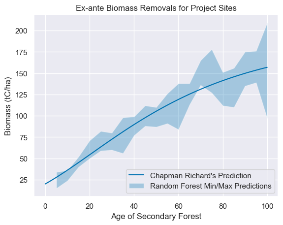

```python
dfMind = pd.read_csv('./growthcurve_mindanao.csv')
dfMind = dfMind.rename(columns={
    dfMind.columns[1] : 'Biomass'
})
dfMind['RF Min'] = dfMind['RF Min'].interpolate()
dfMind['RF Max'] = dfMind['RF Max'].interpolate()
dfMind['RF Mean'] = dfMind['RF Mean'].interpolate()
sns.lineplot(data=dfMind, x='age', y='Biomass', label="Chapman Richard's Prediction")
plt.fill_between(dfMind['age'], dfMind['RF Min'], dfMind['RF Max'], alpha=0.3, label='Random Forest Min/Max Predictions')
plt.xlabel('Age of Secondary Forest')
plt.ylabel('Biomass (tC/ha)')
plt.title('Ex-ante Biomass Removals for Project Sites')
plt.legend(loc='lower right')
plt.savefig('./imgs/robinsoncurve.png')
plt.show()
```

**Scale by hectares planted to get total removals**

```python
p1area =  1560.5
p2area = 3400
dfMind['p1Biomass'] = ((dfMind.iloc[:,1] * p1area) * 44/12).round(decimals=2)
dfMind['p2Biomass'] = ((dfMind.iloc[:,1] * p2area) * 44/12).round(decimals=2)
netRemovals_p1 = dfMind.iloc[:,[0,5]].copy()
netRemovals_p2 = dfMind.iloc[:,[0,6]].copy()
dfMind.head(1)
```

|  | age | Biomass | RF Max | RF Mean | RF Min | p1Biomass | p2Biomass |
| --- | --- | --- | --- | --- | --- | --- | --- |
| 0 | 0 | 20.042 | NaN | NaN | NaN | 114676.98 | 249856.93 |

## Project Emissions

Per section 8.2.2 of the VM0047 methodology, project emissions result from biomass burning and fertilizer use. PEF will not burn any land, so biomass burning is assumed to be 0. However, PEF will be utilizing small amounts of fertilizer. The below equation summarizes project emissions:

[figure not shown]

#### Fertilizer Use

PEF will be utilizing four distinct fertilizers to prep sites and ensure strong saplings. All fertilizers will be made by PEF from natural waste found throughout the nursery areas. It is expected that PEF will utilize these fertilizers from years 1-3 for each project instance. However, PEF will monitor and track their fertilizer use.  
[Attached here](https://docs.google.com/document/d/1Z5JtSc4RT0DZXd64uHlfG_oOwWxp9t6h8AvUT48b8ZU/edit?tab=t.0) is the documentation for how RRG quantified fertilizer use including each fertilizer description.

RRG estimates that per year, project instance 1 will emit **56,577.48 tCo2** from fertilizer use. While project instance 2 will emit **73,411 tCo2e** per year. In total, RRG estimates that project activities will emit **389,964 tCo2** from fertilizer use.

```python
fertilizer_emissions1 = [56577.48, 56577.48, 56577.48]
fertilizer_emissions2 = [73411, 73411, 73411]
# Fill the rest with 0
remaining_years1 = len(netRemovals_p1) - len(fertilizer_emissions1)
remaining_years2 = len(netRemovals_p2) - len(fertilizer_emissions2)
fertilizer_column1 = fertilizer_emissions1 + [0] * remaining_years1
fertilizer_column2 = fertilizer_emissions2 + [0] * remaining_years2
# Add to DataFrame
netRemovals_p1['Fertilizer Emissions (tCo2)'] = fertilizer_column1
netRemovals_p2['Fertilizer Emissions (tCo2)'] = fertilizer_column2
netRemovals_p2.head()
```

|  | age | p2Biomass | Fertilizer Emissions (tCo2) |
| --- | --- | --- | --- |
| 0 | 0 | 249856.93 | 73411 |
| 1 | 1 | 268320.07 | 73411 |
| 2 | 2 | 287244.47 | 73411 |
| 3 | 3 | 306592.73 | 0 |
| 4 | 4 | 326339.93 | 0 |

#### Leakage

Mindanao Island has available data regarding historical grower records and illegal logging rates. However, there is no data available for the Obu-Manuvu people. RRG can see from remote sensing that farms throughout the project zone are quite small and are believed to be subsistence farms.  
Moving into the future, RRG and PEF will complete the FPIC process and hold local farmer interviews to determine foregone production within the project area. Project activities will not displace any farms within the project area. PEF aims to mitigate leakage into the surrounding region by employing these farmers and providing them with an alternate, sustainable livelihood.  
Until the FPIC process occurs, RRG has decided to implement the default leakage deductions set out in the Verra Standard, v4.7. These deductions are taken from the gross Co2e removals and are 15% from activity shifting leakage and 10% from market shifting leakage.  
RRG will ultimately use the VM0054 ARR Leakage module to calculate leakage. This module first estimates leakage by calculating production (based on grower records), an anticipated amount of new land brought into production and the determination of the change in carbon stock due to this land change. Cumulatively, the following equation describes how RRG will quantify leakage.

[figure not shown]

For ex-ante estimations, leakage must be quantified in tCo2. To do this with the default 25% rate, RRG takes 25% of total Co2e removals from each performance scenario.

```python
def leak(mass):
    metric = mass * 0.25
    return(metric)
```

## Net Carbon Removals

Per section 8.5 of the VM0047 methodology, net carbon removals are quantified as follows:

[figure not shown]

**Uncertainty**  
Currently, RRG is using the default uncertainty rate of 10%. Moving into the future, RRG will quantify uncertainty utilizing equation 27 of the VM0047 methodology.

```python
unc = .1
```

**Performance Benchmark**  
Because project activities have just begun, RRG is not currently able to quantify the performance benchmark metric. For ex-ante net carbon removals, RRG has chosen a value of 0. In the immediate future, RRG will complete the performance benchmark analysis.

```python
PB = 0
```

#### Project Instance Breakdown

```python
# quantify net removals
#p1 calc
netRemovals_p1['Net Co2e Removals'] = ((netRemovals_p1.iloc[:,1] * (1- PB) * (1-unc))\
                                     - leak(netRemovals_p1.iloc[:,1])) - netRemovals_p1.iloc[:,2]
# p2 calc
netRemovals_p2['Net Co2e Removals'] = ((netRemovals_p2.iloc[:,1] * (1- PB) * (1-unc))\
                                     - leak(netRemovals_p2.iloc[:,1])) - netRemovals_p2.iloc[:,2]
netRemovals_p2.head()
```

|  | age | p2Biomass | Fertilizer Emissions (tCo2) | Net Co2e Removals |
| --- | --- | --- | --- | --- |
| 0 | 0 | 249856.93 | 73411 | 88996.0045 |
| 1 | 1 | 268320.07 | 73411 | 100997.0455 |
| 2 | 2 | 287244.47 | 73411 | 113297.9055 |
| 3 | 3 | 306592.73 | 0 | 199285.2745 |
| 4 | 4 | 326339.93 | 0 | 212120.9545 |

#### Gross Net Carbon Removals

Project instance 2 will end three years after instance 1 ends.

```python
# select each table merge together
p1 = netRemovals_p1.iloc[:,[0,-1]]
p2 = netRemovals_p2.iloc[:,[0,-1]]
zero_rows = pd.DataFrame(0, index=range(3), columns=p2.columns)
# Concatenate the new rows above the existing data
p2_total = pd.concat([zero_rows, p2], ignore_index=True)
p2_total['Year'] = range(0, len(p2_total))
total = pd.concat([p1.add_suffix('_p1'), p2_total.add_suffix('_p2')], axis=1)
total.head(5)
```

|  | age_p1 | Net Co2e Removals_p1 | age_p2 | Net Co2e Removals_p2 | Year_p2 |
| --- | --- | --- | --- | --- | --- |
| 0 | 0.0 | 17962.5570 | 0 | 0.0000 | 0 |
| 1 | 1.0 | 23470.6830 | 0 | 0.0000 | 1 |
| 2 | 2.0 | 29116.4140 | 0 | 0.0000 | 2 |
| 3 | 3.0 | 91466.0825 | 0 | 88996.0045 | 3 |
| 4 | 4.0 | 97357.2795 | 1 | 100997.0455 | 4 |

```python
total['biomass sums'] = total.iloc[:,1] + total.iloc[:,3]
life = total.iloc[:,-2:]
life = life.rename(columns={
    life.columns[0]:'Year',
    life.columns[1]:'Biomass (tCo2e)'
})
pLife = life[life.iloc[:,0] <= 50]
pLife.tail(1)
```

|  | Year | Biomass (tCo2e) |
| --- | --- | --- |
| 50 | 50 | 1208388.831 |

**In total, RRG anticipates to sequester 1,208,389 tCo2e at year 50.**

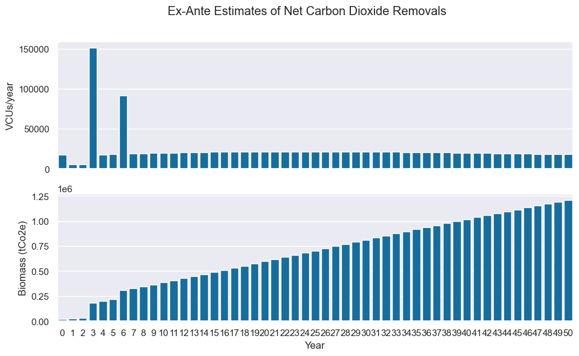

```python
vcu = pLife.copy()
vcu['VCUs/year'] = vcu.iloc[:,1].diff().fillna(vcu.iloc[0,1])
fig, axs = plt.subplots(2, 1, figsize=(11, 6), sharex=True)
sns.barplot(vcu, x='Year', y='VCUs/year', ax=axs[0])
sns.barplot(vcu, x='Year', y='Biomass (tCo2e)', ax=axs[1])
plt.suptitle('Ex-Ante Estimates of Net Carbon Dioxide Removals')
plt.savefig('./imgs/VCUremovals.png')
```

```python
sumVCU = vcu['VCUs/year'].sum()
print(f'In total RRG expects to generate {sumVCU} VCUs')
```

```
In total RRG expects to generate 1208388.831 VCUs
```